# Project Directory — ETF Intelligence

Key Ideas, Key Functions, and Subprojects

2026-04-03

# 1 · Project in One Sentence

A modular R research project that classifies ETF behaviour across three data-driven market regimes (Fall / Recovery / Consolidation) and uses those findings to build and monitor a concrete SAA portfolio with tactical overlays.

# 2 · Key Empirical Findings

## KF1 — Anti-Diversification

key_findings/kf1_anti_diversification.R

**For a long-only blended portfolio, MaxDD is NOT minimised by minimising correlation. It is minimised by minimising the ticker’s own standalone drawdown.**

A ticker with ρ = 0.8 and 15% DD beats a ticker with ρ = 0.1 and 40% DD. Low-ρ tickers systematically underperform the Magdon-Ismail theoretical prediction. High-ρ tickers (> 0.75) track theory closely.

**Implication:** Never add a “diversifier” to reduce portfolio DD without first checking its standalone drawdown. Conventional diversification theory breaks down for long-only portfolios.

**Screen parameters:** full 96-ticker universe, SPY benchmark

**Useful plots**  
`plot_corr_dd(exante_tbl)` — scatter: ρ vs MaxDD, colour by asset class — shows the anti-diversification failure visually  
`plot_exante_quadrant(exante_tbl)` — return vs DD quadrant: low-ρ tickers cluster in the wrong quadrant

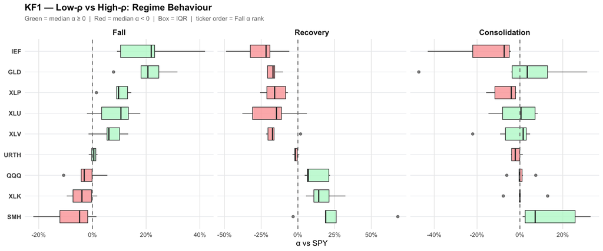

KF1 — Regime fingerprint: low-ρ tickers (GLD, IEF) show HEDGE/STABLE in Fall; high-ρ (XLK, SMH) show LOSS

## KF2 — L/S Pair Selection

key_findings/kf2_ls_pair_selection.R

**To replace SPY weight via a long-ticker / short-SPY overlay, ρ > 0.75 is required.** Only SMH (IR = 0.90), XLK (IR = 0.51), QQQ (IR = 0.48) pass the dual screen. Non-equity assets (GLD, IEF, TLT) are standalone allocations — never L/S legs.

**Screen:** `RHO_SCREEN = 0.75 AND spread MaxDD ≥ −30%`

**Useful plots**  
`KF2-A` — Screening scatter: ρ vs spread MaxDD with valid-candidate zone shaded  
`KF2-B` — IR ranking bar chart of high-ρ candidates (SMH / XLK / QQQ)  
`KF2-C` — ΔMaxDD scatter: IR (x) vs ΔMaxDD (y), circle = P(spread > 0 over 63d)  
`plot_xts_pair(xts_ret[,"SMH"], xts_ret[,"SPY"], ...)` — wealth + rolling ρ + DD comparison

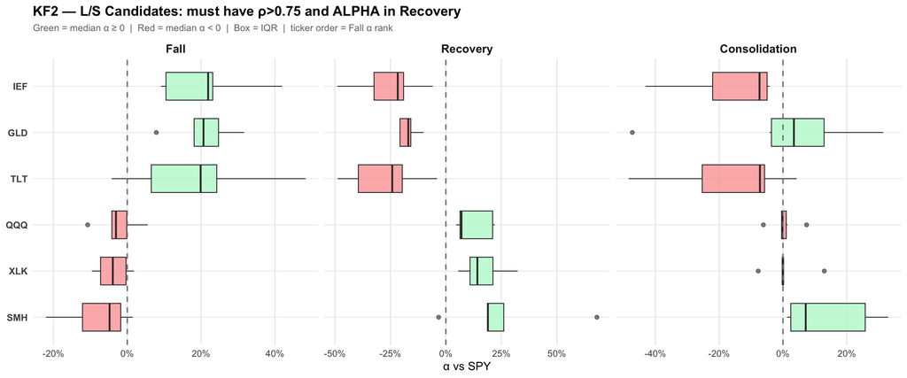

KF2 — Only SMH/XLK/QQQ pass ρ>0.75 screen: they track SPY closely enough for L/S overlay

## KF3 — Trend Reversal at Regime Transitions

key_findings/kf3_trend_reversal.R

**Winner → Loser cohort reversals cluster at regime transitions.** Tickers that led in the prior regime consistently underperform in the new one, particularly at Fall → Recovery transitions.

**Parameters:** `LOOKBACK = 60d`, `PERSIST_N = 3 weeks`, `TRANSIT_WIN = 8 weeks`

**Useful plots**  
`KF3 Plot A` — Transition matrix: winner → loser reversal rates at each regime boundary  
`KF3 Plot B` — Reversal count by regime: bar chart of how often top-quintile tickers reverse  
`KF3 Plot C` — Forward return post-reversal: distribution of returns in 8W after regime flip

[figure not shown]

## KF4 — Cycle Amplifiers (SMH / XLK / QQQ)

memory/project_cycle_amplifiers.md

**Useful plots**  
`plot_regime_fingerprint_box(xts_ret, c("SMH","XLK","QQQ","SPY","GLD","IEF"), rt)` — boxplot per regime: LOSS/ALPHA/ALPHA pattern visible immediately  
`plot_regime_rel_heatmap(xts_ret, c("SMH","XLK","QQQ"), rt)` — episode-level heatmap: see every Fall as LOSS, every Recovery as ALPHA  
`plot_regime_multi_overlay(xts_ret, c("SMH","XLK","QQQ"), master="SPY")` — relative return lines with regime shading

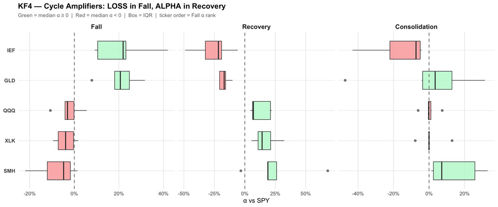

KF4 — LOSS/ALPHA/ALPHA pattern confirmed: SMH/XLK/QQQ dominate Recovery, suffer most in Fall

## KF5 — Regime-Rotation TAA Does NOT Beat Passive 60/40

CLAUDE.md § Critical analytical findings

**Walk-forward DAA: ~6.7% ann. vs passive 60/40: ~7.6%.** Root causes: (1) international diversification drag during US-dominated decade; (2) regime detection lag — Fall fires only after 10% DD already absorbed; (3) tilts too small to overcome base drag. **Do NOT attempt to improve return via regime rotation. The correct objective is DD reduction.**

**Useful plots**  
`plot_multi_wealth_endlabel(list(DAA=..., SAA=..., Passive=...), rt)` — wealth comparison: DAA underperforms passive over full history  
`plot_regime_overlay(xts_ret[,"SPY"], overlay_ret=daa_ret)` — SPY DD with DAA overlay: shows lag in regime detection

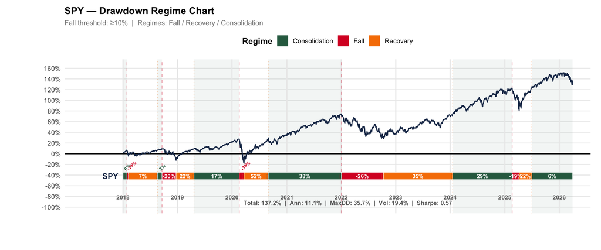

KF5 — SPY regime overlay: Fall fires only after 10% DD already absorbed — the detection lag that kills TAA

## KF6 — DD Overlay Objective

scripts_daa_saa_taa/07_dd_overlay_optimizer.R

**The right question:** “What is the minimum-cost overlay that reduces MaxDD from ~23% to ~15% while accepting SPY/IEF 60/40 return?”

Answer from Pareto frontier of all single/pair/triple combinations screened via `05_dd_stabilizer.R`. Grid search: singles 5–20%, pairs up to 25% total, triples (top 5) up to 25% total.

**Useful plots**  
`plot_dd_frontier(dd_frontier_data)` — arrowed paths: each ticker’s DD vs return as overlay weight sweeps 0→25%; passive diamond anchor  
`plot_multi_wealth_endlabel(target_solutions, rt)` — wealth curves for ≤15% / ≤17% / ≤19% / ≤21% MaxDD target solutions

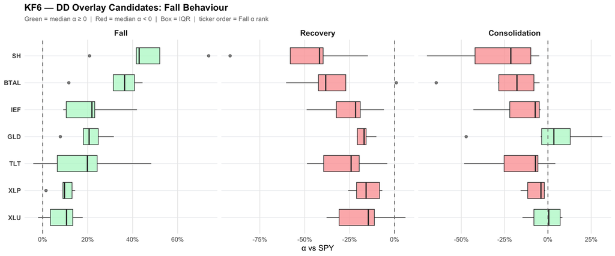

KF6 — DD overlay candidates: Fall regime behaviour of the stabilizer universe

# 3 · Core Analytical Framework

## The Regime Engine

scripts_spy_dd_regime/spy_dd_regime.R

Three-state regime based on SPY cumulative drawdown from running peak:

[output not shown]

build_regime_table(xts_ret_col, t_fall = 0.10)

Returns one row per episode with regime / xmin / xmax / days / return.

**Critical constant — never change without discussion:** `T_FALL = 0.10`

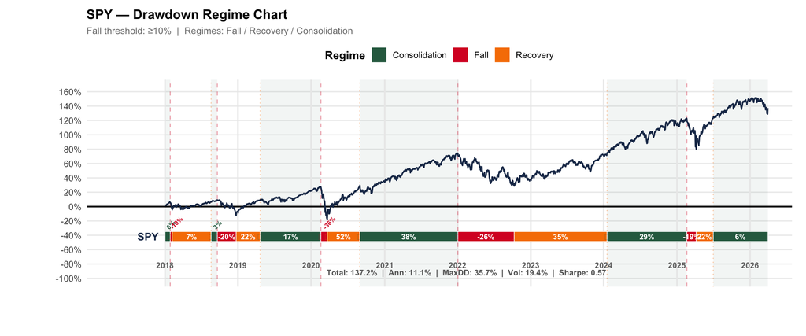

## Outperformance Type Taxonomy

scripts_spy_dd_regime/spy_dd_regime_rel.R

| Type | Condition | Meaning |
| --- | --- | --- |
| **HEDGE** | α>0, abs>0, SPY<0 | Ticker rose while SPY fell |
| **STABLE** | α>0, abs<0, SPY<0 | Both fell — ticker fell less |
| **ALPHA** | α>0, SPY>0 | Both rose — ticker rose more |
| **LAG** | α<0, SPY>0 | Underperformed rising SPY |
| **LOSS** | α<0, SPY<0 | Both fell — ticker fell worse |

Key functions:

plot_regime_fingerprint_box(xts_ret, tickers, rt, master=“SPY”)

plot_regime_rel_heatmap(xts_ret, tickers, master=“SPY”, t_fall=0.10)

get_regime_fingerprint(ticker, xts_ret, rt, master=“SPY”)

**Useful plots**  
`plot_regime_fingerprint_box()` — **primary view**: boxplot per ticker per regime; green = positive median alpha, red = negative; immediately shows XLP/XLU/XLV as Fall hedges and XLK as Recovery leader  
`plot_regime_rel_heatmap()` — episode-level grid: each cell = one episode, colour = outperf_type; reveals consistency across cycles  
`plot_fall_fingerprint()` — Fall only, sorted by mean alpha: who are the true hedges?  
`plot_abs_alpha_regime()` — grouped bars: absolute return + alpha side by side per regime  
`plot_regime_rel_summary()` — faceted avg alpha bars sorted within each regime

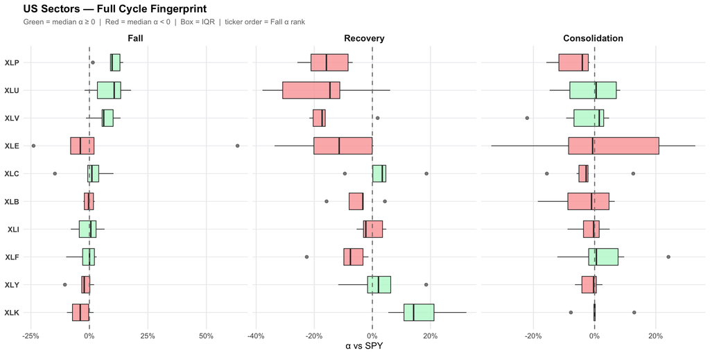

## The SAA Portfolio

```r
SAA_PORTFOLIO <- tribble(
  ~ticker, ~weight, ~asset_class,  ~role,
  "AGG",   0.35,    "Fixed Income", "Core-Stabilizer",
  "URTH",  0.25,    "Equity",       "Anchor",
  "SPY",   0.25,    "Equity",       "Anchor",
  "QQQ",   0.05,    "Equity",       "Core-Growth",
  "XLK",   0.05,    "Equity",       "Core-Growth",
  "SMH",   0.05,    "Equity",       "Satellite"
)
# Equity 65% / Fixed Income 35%
```

**Useful plots**  
`plot_saa_ggbar(SAA_PORTFOLIO, xts_ret)` — bar chart of weights with YTD return annotations  
`plot_saa_treemap()` + `plot_saa_sunburst()` — always shown as a pair: hierarchical weight decomposition  
`plot_multi_wealth_endlabel(list(SAA=..., SPY=..., AGG=...), rt)` — SAA wealth vs components with regime shading  
`plot_ma200_signal_panel(trend_signals, SAA_PORTFOLIO)` — 200DMA status grid for every SAA holding

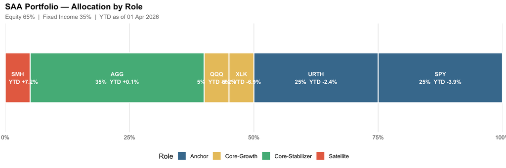

SAA Portfolio — weight composition by role

# 4 · Chart Templates

All templates live in `key_plots/`. Source the file, call the function. Full visual catalogue: `Rmd/plot_directory.Rmd`.

## MA / Price Charts

key_plots/chart_ma_price.R key_plots/chart_ma_cumret.R

plot_ma_chart(ticker, xts_price, from_date=“2020-01-01”, ma1=50, ma2=200, t_fall=0.10)

plot_ma_cumret(ticker, xts_ret, from_date=“2020-01-01”, ma1=50, ma2=200, t_fall=0.10)

Two-panel patchwork: price/cumret + MA lines with amber/red ribbon shading; drawdown panel.

## MA Range & Distance

key_plots/chart_ma_range.R

plot_ma_range(ticker, xts_ret, from_date, ma1=50, ma2=200, win_52w=252, compact=FALSE)

3-panel (or 2-panel compact): cumret + 52W band / % distance from 52W Hi–Lo / % distance from MAs.

## Price Position Ruler (Gauge) ★ canonical v3 — locked 2026-03-30

key_plots/chart_ma_range.R

plot_ma_gauge(tickers, xts_ret, ma1=50, ma2=200, win_52w=252, flip=FALSE)

One horizontal ruler per ticker. All references expressed as % distance from current price (0% anchor). State classifier (6 states): Bear / Trending / Stretched / Pullback / Stressed / Correction.

State colours:

[output not shown]

## SPC Control Chart

key_plots/chart_ma_range.R

plot_gauge_spc(tickers, xts_ret, ma1=50, ma2=200, win_52w=252, sort_by=“none”)

Shewhart-inspired cross-sectional chart. Centre = 200DMA (0%). Zones: ±1σ green / ±2σ amber. Grey bar = 52W Hi–Lo. State-coloured lollipop = % from 200DMA. Orange circle = 50DMA.

`sort_by = "norm_pos"` orders tickers oversold → overbought.

**Conceptual precedent:** Shewhart control charts (1924) / phase diagrams / sufficient statistics (Fisher 1922).

## Other Templates

| Template | File | Function |
| --- | --- | --- |
| Multi-wealth end-label | `chart_multi_wealth_endlabel.R` | `plot_multi_wealth_endlabel(ret_list, rt)` |
| 200DMA signal panel | `chart_ma200_signal_panel.R` | `plot_ma200_signal_panel(trend_signals, saa_tbl)` |
| Stacked weight timeline | `chart_stacked_weight_timeline.R` | `plot_stacked_weight_timeline(weight_tbl, saa_tbl, rt)` |
| DD frontier | `chart_dd_frontier.R` | `plot_dd_frontier(dd_frontier_data)` |
| P/E bands | `chart_pe_bands.R` | `plot_pe_bands(n_years=10)` |
| Calendar heatmap | `calendar_heatmap.R` | `plot_calendar_heatmap(ticker, n_yr=5)` |
| Stock return matrix | `chart_stock_matrix.R` | `plot_stock_matrix(from_yr=1900)` |

# 5 · Technical Posture Framework

## Fingerprint Vector

key_plots/chart_ma_range.R

**The sufficient statistic for tactical decisions:** `v = [state, d_52W_hi, d_200DMA, d_50DMA, dd_pct, d_52W_lo]`

Discards price history that doesn’t change the action. All distances in % from current price. Scale-free via z-score normalisation (÷ annualised σ).

build_gauge_vectors(tickers, xts_ret, ma1=50, ma2=200, win_52w=252)

Returns tibble: `ticker | state | d_52w_hi | d_200dma | d_50dma | dd_pct | d_52w_lo | norm_pos | sigma | z_*`

**norm_pos** ∈ [0, 1]: 0 = at 52W low, 1 = at 52W high. Use for sorting and ranking.

**Useful plots**  
`plot_ma_gauge(saa_tickers, xts_ret)` — **primary snapshot**: one ruler per ticker, current posture at a glance  
`plot_ma_gauge(..., flip=TRUE)` — horizontal layout for presentations  
`plot_gauge_spc(saa_tickers, xts_ret, sort_by="norm_pos")` — SPC chart sorted oversold→overbought; zone bands show who is extended  
`plot_ma_range(ticker, xts_ret)` — single-ticker deep-dive: cumret + 52W band + all distance panels  
`plot_ma_cumret(ticker, xts_ret)` — single-ticker with MA crossover shading + drawdown panel

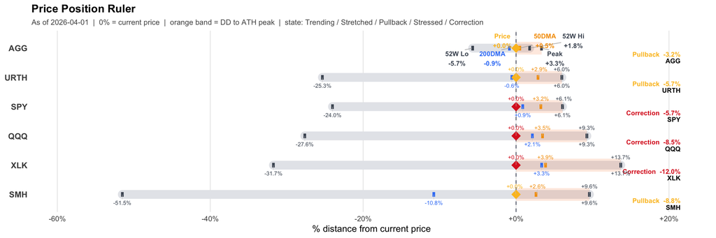

Price Position Ruler — canonical v3: state-coloured diamond, DD shading, 52W range bar

## Similarity Heatmap

plot_gauge_similarity(tickers, xts_ret, method=“euclidean”)

Pairwise Euclidean distance on z-score vector. Clustered by Ward D2. Blue = similar posture (concentration risk). Red = opposite posture (genuine diversification).

**Useful plots**  
`plot_gauge_similarity(saa_tickers, xts_ret)` — **portfolio concentration check**: are your 6 SAA holdings truly independent or do 3 of them cluster?  
`plot_gauge_similarity(universe_tickers, xts_ret)` — full universe: find genuine diversifiers (high distance from current SAA holdings)

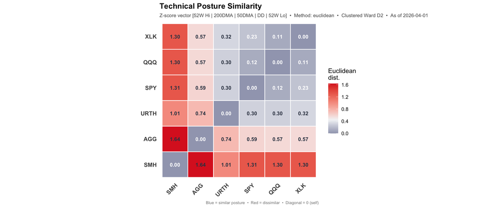

Technical Posture Similarity — Euclidean distance on z-score vector; blue=similar (concentration risk)

**Cosine distance collapses to ~0 when all tickers are in the same regime** (same-direction z-vectors). Always use `method = "euclidean"` as default. Cosine only meaningful in mixed-regime universes.

## Daily Panel Tracker

scripts/gauge_panel_tracker.R

log_gauge_snapshot(tickers, xts_ret)

load_gauge_panel()

plot_gauge_norm_pos(panel, tickers)

plot_gauge_state_history(panel, tickers)

Logs daily fingerprint snapshots to `02_data_processed/gauge_panel.rds`. Add `log_gauge_snapshot()` to `master_run.R` for automatic daily logging.

**Useful plots**  
`plot_gauge_norm_pos(panel, saa_tickers)` — time series of 52W position per ticker: are holdings drifting toward highs or lows over weeks?  
`plot_gauge_state_history(panel, saa_tickers)` — **regime transition early warning**: tile chart shows when clusters of holdings flip state simultaneously

[figure not shown]

# 6 · Subproject — What Has Happened

*Goal: replace visual chart noise with structured, threshold-aware regime intelligence.*

## Function A — The Dynamics

scripts_what_happened/dynamics.R

build_dynamics(tickers, xts_ret, etf_metadata)

plot_dynamics(dyn, groups=NULL, periods=c(“WTD”,“MTD”,“QTD”,“YTD”))

Returns period returns (WTD / MTD / QTD / YTD) for all tickers grouped by **factor style**:

`US Momentum | Cyclical Growth | Cyclical Value | Quality | Defensive | Global Equity | DM Intl | Emerging Markets | FI Gov | FI Credit | Inflation Shield | Real Estate | Alternatives | FX | Biotech | Defense`

Visualisation: red/green heatmap grouped by factor style, sorted by YTD within each group. Reading: which rows are green across all 4 periods = what the market is rewarding right now.

```r
dyn <- build_dynamics(colnames(xts_ret), xts_ret, etf_metadata)
plot_dynamics(dyn)
plot_dynamics(dyn, groups = c("US Momentum","Cyclical Growth","Cyclical Value",
                               "Quality","Defensive","Global Equity"))
```

**Useful plots**  
`plot_dynamics(dyn)` — **full universe heatmap**: which factor styles are green across WTD/MTD/QTD/YTD = the Zeitgeist  
`plot_dynamics(dyn, groups=c("US Momentum","Cyclical Growth","Cyclical Value","Quality","Defensive"))` — equity styles only: factor rotation snapshot  
`plot_dynamics(dyn, groups=c("FI Gov","FI Credit","Inflation Shield"))` — fixed income + real assets: flight-to-safety vs risk-on in bonds

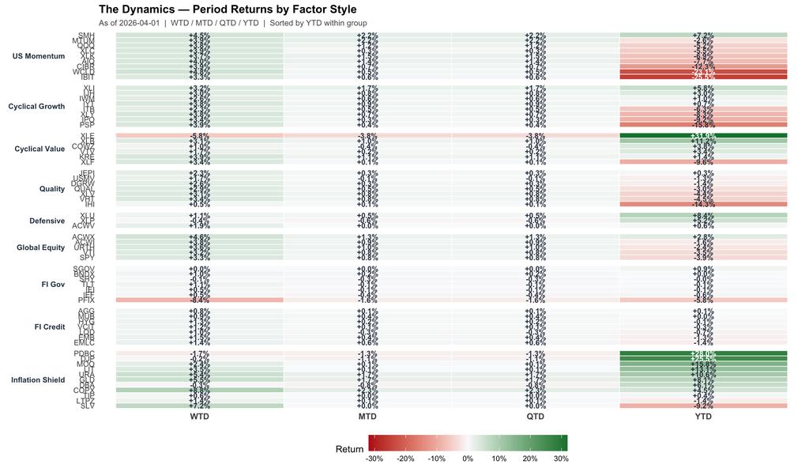

The Dynamics — period returns by factor style: read green rows = what the market rewards now

## Function B — Regime Rank

scripts_what_happened/regime_rank.R

rank_regime_etfs(tickers, xts_ret, rt, master=“SPY”, n_top=NULL, etf_metadata=NULL, asset_class=NULL, pf_function=NULL)

plot_regime_rank(ranking_tbl, n_top=15)

Ranks every ETF by usefulness in each regime using composite score:

[output not shown]

`consistency` = % of historical episodes with positive alpha (robustness signal).

```r
# Equities only, Fall ranking
rk <- rank_regime_etfs(tk, xts_ret, rt,
                        etf_metadata = etf_metadata,
                        asset_class  = "Equity")
plot_regime_rank(rk %>% filter(regime == "Fall"), n_top = 12)

# Fixed income vs IEF benchmark
rk_fi <- rank_regime_etfs(tk, xts_ret, rt,
                           master       = "IEF",
                           etf_metadata = etf_metadata,
                           asset_class  = "FixedIncome")
plot_regime_rank(rk_fi)
```

**Useful plots**  
`plot_regime_rank(rk, n_top=12)` — **3-panel lollipop**: top N per regime coloured by HEDGE/STABLE/ALPHA/LAG/LOSS; read Fall panel to find hedges, Recovery panel to find amplifiers  
`plot_regime_rank(rk %>% filter(regime=="Fall"), n_top=15)` — Fall only: who are the true hedges ranked by alpha + consistency?  
`plot_regime_fingerprint_box()` — complementary view: same data as boxplots for visual confirmation

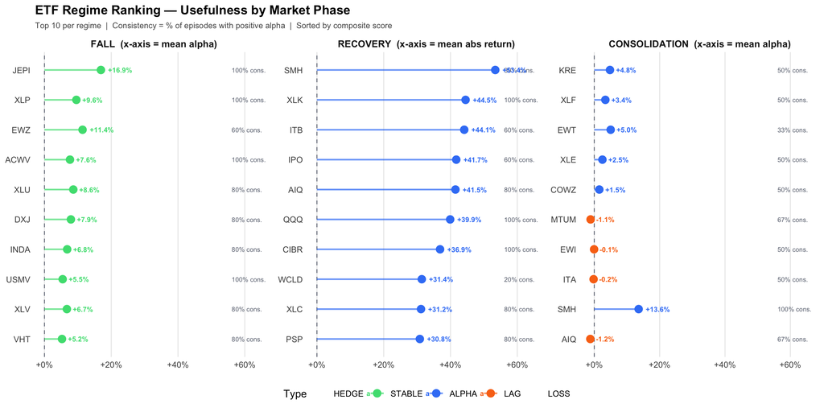

Regime Rank — top ETFs by usefulness per regime: Fall hedges / Recovery amplifiers / Consolidation alpha

# 7 · Market State Framework (3 Layers)

scripts_market_state/

| Layer | Function | Output |
| --- | --- | --- |
| L1 Vector State | `build_market_state_history(xts_ret)` | 5 states: Expansion / US-Led / Late-Cycle / Deterioration / Contraction |
| L2 Sector Pattern | `build_sector_pattern_history(xts_ret)` | Cyclical vs Defensive momentum → Risk-On/Off |
| L3 Risk Allocation | `build_risk_allocation_history(xts_ret)` | Final EQ/FI weight [25%–75%] |

5 signals driving L1: URTH regime | SPY regime | US premium (60d) | EM appetite (60d) | sector breadth

```r
plot_ms_dashboard(xts_ret)    # 3-panel patchwork summary
print_market_state(ms_hist)   # console current state
print_risk_allocation(ra_hist) # current EQ/FI
```

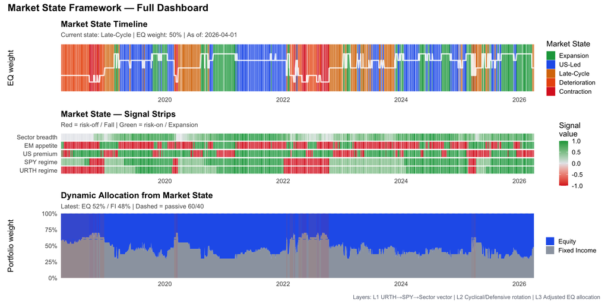

# 8 · Session Startup Sequence

```r
source("00_libraries.R")                         # packages + build_regime_table()
source(here("scripts/00_init_universe.R"))        # etf_metadata (108 tickers)
source(here("scripts/01_etf_wrangle.R"))          # xts_ret, xts_ret_winsor, xts_rel
rt <- build_regime_table(xts_ret[, "SPY"])        # explicit assign — avoids stats::rt shadow

# Gauge framework
source(here("key_plots/chart_ma_range.R"))        # plot_ma_gauge, plot_gauge_spc,
                                                   # build_gauge_vectors, plot_gauge_similarity

# What Has Happened
source(here("scripts_spy_dd_regime/spy_dd_regime_rel.R"))
source(here("scripts_what_happened/dynamics.R"))
source(here("scripts_what_happened/regime_rank.R"))
```

# 9 · Critical Rules (Never Violate)

1. **T_FALL = 0.10** — never change the regime threshold without discussion
2. **Objective is DD reduction, not return maximisation** — confirmed by KF5
3. **Low ρ ≠ low portfolio DD** — confirmed by KF1
4. **Sunburst + treemap are always a pair** — update/show both together
5. **xts_ret_winsor for sigma/z-scores only** — distorts cumulative returns
6. **rt ← build_regime_table(…)** — must assign explicitly (stats::rt shadows)
7. **Always use here::here() + envir=new.env() for parameterised Rmd renders**
8. **Never show a 3-state transition matrix** — trivially 100% by construction

# 10 · Universe Quick Reference

108-ticker Sovereign Universe. Key fields in `etf_metadata`:

| Field | Values |
| --- | --- |
| `asset_class` | Equity / FixedIncome / Commodity / FX / RealAsset / MultiAsset / Alternative |
| `tree_level` | L1_World / L2_Region / L3_Country / L3_Sector / Factor / Satellite / FI_Gov / … |
| `pf_function` | Anchor / Core-Growth / Core-Stabilizer / Core-Income / Core-Factor / Tactical / Real-Shield / Satellite / DAA |
| `geo` | US / Global / DM / EM / Multi |

```r
# Quick filters
etf_metadata %>% filter(asset_class == "Equity", pf_function == "Anchor")
etf_metadata %>% filter(tree_level == "L3_Sector")
etf_metadata %>% filter(pf_function == "DAA")
```